# Flux-based hierarchical organization of *Escherichia coli*'s metabolic network

## 3.1. Flux levels and the flux order relation

Let's plot the histogram and cumulative distribution of average data differences obtained from flux level data. In both plots, results generated with the actual (unpermuted) data are depicted in blue while those coming from the permutation analysis are depicted in gray. Additionally, we plot the range covered by all $n=10000$ cumulative distributions generated in the permutation analysis (gray-shaded region in the left plot) as well as the cumulative distribution corresponding to the sum of all $n$ distributions of (permuted) data differences, depicted in black in the left plot — the sum of all $n$ distributions generated in the permutation is depicted in gray in the plot on the right.

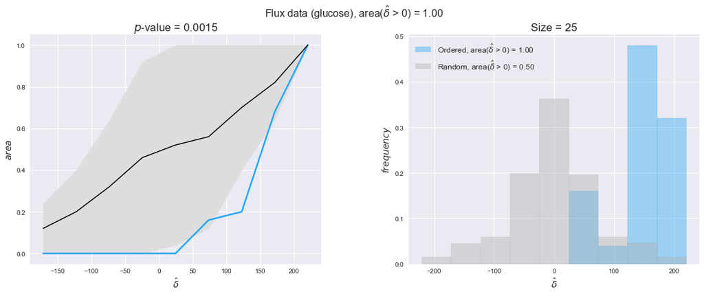

```python
flux_plot = pm.plotDataOrder(flux_plot_data, data_colors['flux'], interactive=False)
```

We see that flux data satisfy the flux order relation in all cases, i.e., in all 25 flux-ordered pairs with available data, the difference of reaction flux levels is always positive. Moreover, the low $p$-value = 0.0015 indicates that these results are likely to be significant. This result is in line with what we would expect since flux level data is the only data type directly comparable to our prediction on the ordering of fluxes.

While the previous was a very good result, it could be an artifact. Estimating flux levels from ${}^{13}\mathrm{C}$ measurements *requires* a metabolic network. The largest part of the flux data used in this study comes from , in which authors employed a small metabolic network, covering the central carbon metabolism, to calculate the flux levels that better explained the ${}^{13}\mathrm{C}$ measurements. It could be possible that the small metabolic network, here termed experimental network, produced a set of flux-ordered reaction pairs that was also within the set of flux-ordered pairs of iJO1366. If this were to be the case, then the order relation observed in the flux level data would be a necessary consequence of the method employed to obtain the data and not a reflection of the order relation in iJO1366. To investivate this issue, we will find the flux-ordered pairs of the experimental network and evaluate if they are in fact within the set of flux-ordered pairs of iJO1366. Let's start by importing the experimental network which was obtained from supplementary Sfigure2 of the above publication and computing the flux-ordered pairs here.

```python
FluxDataNetwork = pd.read_excel(workDir + '/Models/FluxDataNetwork/FluxDataNetwork.xlsx', header=4, index_col=0)
n_mets_exp, n_rxns_exp = FluxDataNetwork.shape
print('Experimental network imported with {} reactions and {} metabolites'.format(n_rxns_exp, n_mets_exp))
```

```
Experimental network imported with 54 reactions and 28 metabolites
```

Let's continue and compute the flux-ordered reaction pairs of the experimental network. This metabolic network was directly obtained from an excel file instead of being part of a cobra model. For this reason, we will use a dedicated function to find flux-ordered pairs in this case instead of using the class Model as before.

```python
FluxDataNetwork_Orders_DataFrame = hm.getFluxOrdersForFluxDataNetwork(
    FluxDataNetwork, carbonUptakeRate=20, fva_filter=True)
```

```
There are: 211 candidate pairs out of 1431 total pairs
There are: 92 ordered pairs out of 211 candidate pairs
```

We see that indeed the experimental network is capable of generating flux-ordered reaction pairs, a total of 92 (6.4%) pairs. Next, we look at the intersection between this set and the set of flux-ordered pairs of iJO1366.

```python
iJO1366_Orders_DataFrame = hm.getFluxOrderDataFrame(iJO1366_A['glucose'], iJO1366['glucose'])
shared_ordered_pairs = hm.getSharedOrderedPairs(
    FluxDataNetwork_Orders_DataFrame, iJO1366_Orders_DataFrame, reactionsWithData=fluxValues.keys())

shared_ordered_pairs['total']
```

```
[['CS', 'ICL'],
 ['ACONTa', 'AKGDH'],
 ['ACONTa', 'ICL'],
 ['FUM', 'ICL'],
 ['FUM', 'MALS'],
 ['ENO', 'ENO_reverse'],
 ['ACONTb', 'AKGDH'],
 ['ACONTb', 'ICL']]
```

```python
shared_ordered_pairs['with data']
```

```
[['CS', 'ICL'], ['FUM', 'ICL'], ['FUM', 'MALS'], ['ACONTb', 'ICL']]
```

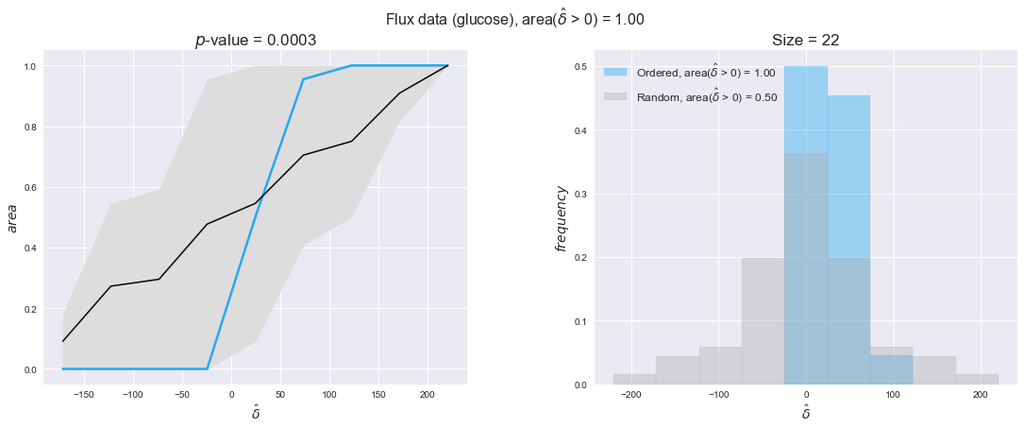

```python
flux_plot_data_ExpNet = DataOrderEvaluator(
    FluxDataNetwork_Orders_DataFrame, data=fluxValues).evaluateDataOrderRelation(samplesize=10000)
flux_plot_ExpNet = pm.plotDataOrder(
    flux_plot_data_ExpNet, data_colors['flux'], interactive=False)
```

Once again, we see that flux levels respect the flux order relation in all cases, i.e., 22 flux-ordered pairs with available data in the experimental network. Furthermore, the obtained experimental $p$-value indicates that this result is solid. We conclude that flux levels do entirely respect the flux order relation. Next, we will investigate to what extent this result holds when using other, indirect measurements of reaction rate

## 3.2. Transcript and protein levels and the flux order relation

Here, we conduct the same analysis that we performed in the previous section. However, this time we will use transcript and protein levels. These data types differ from flux levels in two ways. On the one hand, these are indirect measurements of flux rate, at best we can hope for some correlation between transcript and protein levels and flux levels. This is because reaction flux not only depends on the amount of enzyme (even less on the amount of gene transcripts) that is available. Specifically, reaction flux is a rather complicated function of the amount of *active* enzyme catalytic centers — including the possibility here of enzyme regulation — enzyme catalytic rate and metabolite concentrations. On the other hand, we have a markedly larger set of data values for each reaction and a greater coverage since i) enzymes can be coded by more than one gene and ii) current technology makes it easier and more accessible to measure transcript and protein levels than flux levels and it is not limited to reactions in central carbon metabolism. Let's then continue our analysis evaluating the flux-order relation in transcript data. Remember that in both, transcript and protein data, we will consider the three carbon sources as well as the metabolic cost required to synthesize enzymes. Consequently, we generate a total of 12 plots — three carbon sources and four cost thresholds for each carbon source.

```python
transcript_plots = pm.plotDataOrder(int_plots_data['transcript'], data_colors['transcript'], interactive=True)
transcript_plots
```

**Carbon source**:  
**Percentile**:

[figure not shown]

We begin analyzing growth on glucose when including all flux-ordered reaction pairs, i.e., the cost threshold is the $\mathrm{P}_0$ percentile of the cost distribution. We see that transcript levels follow the flux order relation in 63% of the cases and this result is significant with a fairly low experimental $p$-value = 0.0005, that's 5 times the minimum possible for this study. This result indicates that transcript levels do partially follow the flux-order relation, which is is line with the hypothesis that enzyme levels are regulated to match the flux order relation to avoid unnecessary (over)production of enzyme. What would happen if we selectively look at the sets of flux-ordered pairs with increasing enzyme costs? Upon changing the cost percentile, we can see that the fraction of average positive differences increases from 63% at $\mathrm{P}_0$ to 83% at $\mathrm{P}_{85}$. This result further supports our hypothesis, the expression of enzymes with greater costs is more strongly regulated to match the flux order relation as to minimize the total costs derived of producing unneeded enzyme units.

Results are not as clear, however, when we analyze the other two carbon sources. While data associated to flux-ordered pairs also tends to follow the flux order relation, the fraction of positive average differences stays unchanged across increasing cost thresholds, ranging from 62% to 66% in both carbon sources. It may be that enzyme costs, which are measured as moles of carbon source consumed per mol of protein synthesized, are more accurate in the case of glucose that in the case of acetate — there is not cost data for glycerate, we have employed glucose costs in this case. Let's continue our analysis with the protein data set which represent a better proxy of reaction fluxes.

```python
protein_plots = pm.plotDataOrder(int_plots_data['protein'], data_colors['protein'], interactive=True)
protein_plots
```

**Carbon source**:  
**Percentile**:

[figure not shown]

We observe that protein levels tend to follow the flux order relation in all three carbon sources, with fraction of positive average differences of 60% for glucose and glycerate and of 58% for acetate, and $p$-values ranging from 0.01 for glucose to 0.03 for acetate. Additionally, similar to transcript data, the fraction of positive differences grows with increasing enzyme production costs, although only in the case of glucose and glycerate as carbon sources. When employing acetate as carbon source, the fraction of positive differences is only significant at $\mathrm{P}_0$.

To conclude this section, we have seen that transcript and protein data follow the flux order relation to some extent. Additionally, in line with our hypothesis about minimizing enzyme production costs, data tend to better follow the flux order relation in the case of costly enzymes. However, the latter results only hold under glucose in the case of transcript data and glucose and glycerate in protein data.

## 3.3. Enzyme $k_{cat}$ values and the flux order relation

Finally, we consider a fundamental property of enzymes: the catalytic constant, $k_{cat}$. $k_{cat}$ values are ultimately result of physicochemical properties of the enzymes, and, hence, are not affected by enzyme regulation or by environmental effects such as the available carbon source. For this reason, we will test the same $k_{cat}$ data on all three sets of ordered pairs, one per carbon source. We should obtain similar results across carbon sources. We only have one data value per reaction, so here we compute the distribution of data differences $\delta$ instead of average differences as before.

```python
kcat_plot = pm.plotDataOrder(kcat_plot_data, data_colors['kcat'], interactive=True, has_protein_costs=False)
kcat_plot
```

**Carbon source**:

[figure not shown]

We see that $k_{cat}$ values produce positive differences in approximately 80% of the cases when we use models across carbon sources, thus suggesting that enzymes have optimized this property during evolution to match the flux order relation. Additionally, the $p$-value = $10^{-4}$ is the smallest possible, i.e. none of the samples in the permutation analysis produced an equal or more extreme observation, thus results are solid. There are two observations here. On the one hand, optimizing $k_{cat}$ values would further minimize metabolic costs since increasing reaction rate to match the order relation would be done by modifying the catalytic rate instead of the number of enzyme copies. On the other hand, there is experimental evidence indicating that many enzymes, particularly in central metabolism, operate under substrate saturation — in conditions in which reaction rate is independent of substrate concentrations. In this latter case, $k_{cat}$ values correlate even better with reaction fluxes since reaction fluxes no longer depend on metabolite concentrations.

## 3.4. Gene regulatory interactions and the flux order relation

Reactions situated in higher positions in the hierarchical graph depicting the flux order relation control the flux upper bound of larger sets of reactions than those situated in lower positions. Hence, by regulating the activity through reactions in upper levels, a cellular system could more efficiently control the flux through the metabolic network. We will next investigate whether coding genes of enzymes catalyzing reactions in upper layers tend to be more transcriptionally regulated than those situated in lower levels. To this end, we will partition the 19 levels of the flux order DAG corresponding to glucose into three groups which roughly contain the same number of reactions: the first, middle and last group. As discussed in the introduction to this section, we consider here the total number of regulatory interactions per gene, i.e., both activating and inhibtory. Let's (box)plot the distributions of total number of regulatory interactions per group.

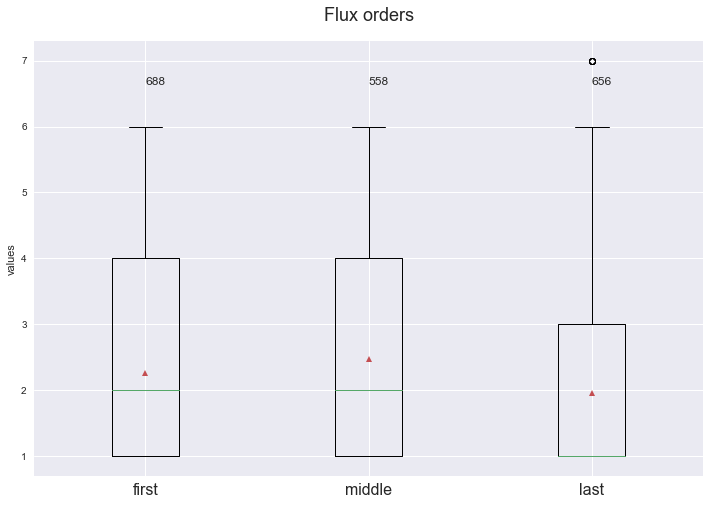

```
Level first > last, with p-value = 0.00072
Level middle > last, with p-value = 0.0
```

```python
# Evaluate regulatory interactions in the flux order DAG
GraphDataEvaluator = DataOrderEvaluator(iJO1366_Orders_DataFrame, Model=iJO1366['glucose'], data=geneRegulationData)
evalFluxOrderRegulations = GraphDataEvaluator.evaluateGeneDataPerGraphLevel(
        Graph_Levels['glucose'], statistic='mean', sampleSize=10,
        plotTitle='Flux orders', group_levels=True)

for comparison in evalFluxOrderRegulations['pvalues']:
    print('Level {} > {}, with p-value = {}'.format(comparison[0][0], comparison[0][1], comparison[1]))
```

It seems like the genes of reactions in the first and middle groups tend to be more regulated than those in the last group while the first and middle groups look alike. After applying a one-sided Mann-Whitney test, we obtain significant $p$-values only in the first-last and middle-last comparisons.

A similar analysis was conducted in , where authors reconstructed the directional flux coupling DAG corresponding to *E. coli*'s metabolic network. Authors found a positive association between the DAG level and the gene regulation state (regulated vs no regulated). Hence, we conducted a similar analysis and reconstructed the directional flux coupling DAG of of *E. coli*, employing this time the same data set as before: total number of regulatory interactions per gene. We will next reconstruct the flux-coupling DAG.

```python
# Reconstruct the flux-coupling DAG
iJO1366_B = hm.getDirectionalCouplingAdjacencyMatrix(iJO1366_fctable)

iJO1366_Coupling = FluxOrder(iJO1366['all'], AdjacencyMatrix=iJO1366_B, fctable=iJO1366_fctable)
Coupling_Graph = iJO1366_Coupling.getGraph()
Coupling_Graph_Levels = Coupling_Graph.getGraphLevels()
```

```
Extracting reactions in flux order DAG levels...
```

```
There are a total of 1590 reactions in the flux coupling DAG
```

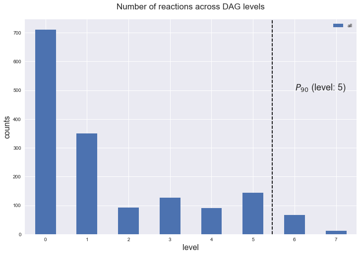

```python
Coupling_Levels = {'all': Coupling_Graph_Levels}
df = pm.plotNumberOfReactionsPerGraphLevel(Coupling_Levels)
print('There are a total of {} reactions in the flux coupling DAG'.format(df.sum()[0]))
```

Our flux-coupling DAG contains a total of 1590 reactions distributed across 8 graph levels. Similar to the flux order DAG, the first two levels contain the majority of reactions in the DAG. Let's now evaluate whether, here too, the number of gene regulatory interactions is higher in the first levels in comparison to the last levels.

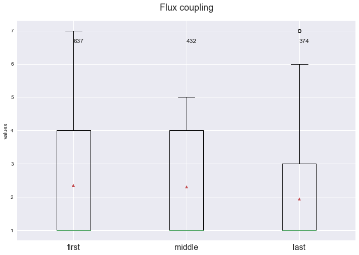

```
Level first > last, with p-value = 0.00048
Level middle > last, with p-value = 0.00267
```

```python
# Evaluate regulatory interactions in the directional coupling DAG
iJO1366_CouplingDataFrame = hm.getFluxOrderDataFrame(iJO1366_B, iJO1366['all'])
GraphDataEvaluator = DataOrderEvaluator(iJO1366_CouplingDataFrame, Model=iJO1366['all'], data=geneRegulationData)
evalCouplingRegulations = GraphDataEvaluator.evaluateGeneDataPerGraphLevel(
        Coupling_Graph_Levels, statistic='mean', sampleSize=10,
        plotTitle='Flux coupling', group_levels=True)

for comparison in evalCouplingRegulations['pvalues']:
    print('Level {} > {}, with p-value = {}'.format(comparison[0][0], comparison[0][1], comparison[1]))
```

We obtain a result that is qualitatively identical to the one obtained with the flux-order DAG. Namely, genes of reactions in the first and middle groups of levels show significantly larger numbers of total gene regulatory interactions. These results are also aligned with the ones obtained in .

To conclude this section, we have seen that diverse types of experimental data tend to respect the flux order relation. ${}^{13}\mathrm{C}$-derived flux levels are the only data type that can directly reflect the flux order relation and, indeed, we saw that they match the flux order relation in all cases. However, we have also seen that other, indirect measurements of flux levels tend to follow the flux order relation. This is particularly marked in the case of enzyme specific activities, $k_{cat}$ values and transcript and protein data when enzyme production costs are high. These observations support the hypothesis that *E. coli* has evolved to sustain enzyme levels and activities that match the flux order relation to avoid the overproduction of unnecessary enzyme units, hence minimizing costs. Finally, we saw that genes of reactions situated in the first levels of the flux order DAG tend to be more regulated, at least to some extent, than those of reactions in the last levels. This observation aligns with the fact that reactions in higher positions in the DAG have a greater capacity to control metabolic flux, since they constrain the flux of a greater number of reactions.

# 4. On reaction essentiality

Identifying essential reactions — reactions that must carry non-zero flux to enable cellular growth — is crucial in both biotechnological and biomedical settings. For instance, in the first case, essential reactions and their genes form a set that cannot be removed during metabolic pathway optimization approaches. In the second case, essential reactions and their enzymes provide potential targets to halt the growth of pathogens .

All reactions that are flux-ordered with the biomass (pseudo)reaction are also essential, due to the flux upper bound imposed on biomass production. However, it is unclear whether all essential reactions are also flux-ordered with the biomass reaction. We will next investigate to what extent essential reactions are also flux-ordered with the biomass reaction. To this end, we will evaluate the intersection between the set of all reactions that are essential for growth on glucose — identified with cobrapy's native *find_essential_reactions* — and then of flux-ordered and essential reactions, i.e., all ancestors of the biomass reaction in the flux order DAG corresponding to glucose. Let's first compute the set of essential reactions and continue extracting the subDAG formed by all ancestors of the biomass reaction in the flux order DAG.

```python
# Extract subDAG of biomass ancestors
biomass_rxn_id = 'BIOMASS_Ec_iJO1366_WT_53p95M'
G = iJO1366_Orders_DAG['glucose'].G
Ordered_essential_reactions = nx.ancestors(G, biomass_rxn_id)
Ordered_essential_reactions.remove('ATPM')
Ordered_essential_reactions.add(biomass_rxn_id)
Essential_G = G.subgraph(Ordered_essential_reactions)
# nx.write_gml(Essential_G, path='Essential_G.gml')

# Compute essential reactions using cobrapy
FBA_essential_reactions = find_essential_reactions(iJO1366['glucose'].GEM)
FBA_essential_reaction_ids= set([rxn.id for rxn in FBA_essential_reactions])
Essential_reactions_intersect = FBA_essential_reaction_ids.intersection(Ordered_essential_reactions)

n_essential = len(FBA_essential_reactions)
n_essen_ord = len(Essential_reactions_intersect) - 1
print(('There are a total of {} essential reacitons '
       'out of which {} are also flux-ordered with '
       'the biomass reaction').format(n_essential, n_essen_ord))
```

```
There are a total of 374 essential reacitons out of which 27 are also flux-ordered with the biomass reaction
```

[figure not shown]

These are all the ancestors of the biomass reaction in the flux order DAG. Note that reactions are colored based on their metabolic macrosystems. It is not surprising to see that the four represented macrosystems: *Transport*, *Carbohydrate metabolism*, *Aminoacid metabolism* and *Energy and maintenance* are all critical to sustain growth.

We saw that the majority of essential reactions are not flux-ordered, however, this result is counterintuitive, provided that the flux order relation imposes an upper flux bound on the biomas reaction. We can understand the previous result by visualizing the flux space of two different reactions with the biomass reaction: one reactions which is only essential and another that is essential and flux-ordered with the biomass reaction. Let's start with reaction *Geranyltranstransferase* (GRTT), a reaction that is only essential.

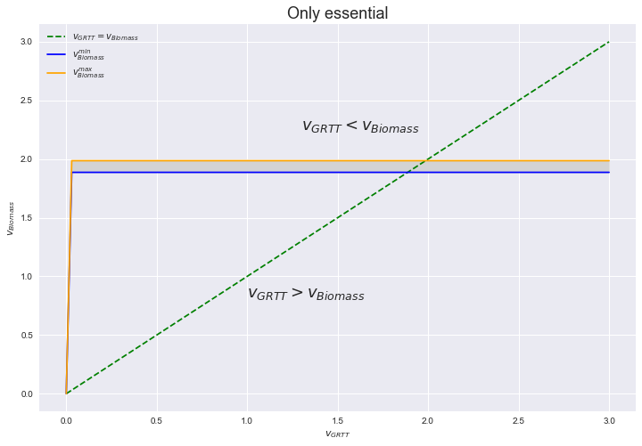

```python
# Plot only essential solution space
rxn_i_id = 'GRTT' #list(FBA_essential_reactions)[4]  # essential but not ordered
pm.plotSolutionSpace(iJO1366['glucose'].GEM, rxn_i_id, biomass_rxn_id, v_i_max=3,
                  n_points=100, plot_diagonal=True, r_j_nickname='Biomass',
                  plot_title='Only essential')
```

In this case, we see that the pair of reactions take flux values which are both above and below the line of equal fluxes $v_i = v_j$ (green dotted line) and the flux through biomass abruptly becomes zero when $v_{GRTT} = 0$. Hence, reaction GRTT *is* essential but cannot be flux-ordered. Let's now pick a reaction from the set of essential and flux-ordered reactions:

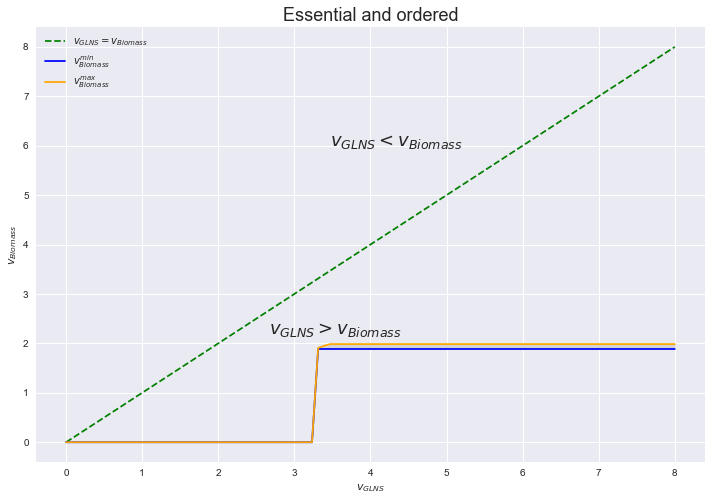

```python
# Plot ordered and essential solution space
rxn_i_id = 'GLNS'  # ordered and essential
pm.plotSolutionSpace(iJO1366['glucose'].GEM, rxn_i_id, biomass_rxn_id, v_i_max=8,
                  n_points=100, plot_diagonal=True, r_j_nickname='Biomass',
                  plot_title='Essential and ordered')
```

We have picked reaction *Glutamine synthetase* (GLNS), in this case, we see that the flux space of the two reactions is always below the green dotted line, hence $v_{GLNS} \geq v_{Biomass}$ holds in any steady-state and GLNS is both essential and flux-ordered with the biomass reaction.

# 5. Conclusions

As a final conclusion, we have shown that the metabolic network of *E. coli* displays a new property when operating at steady state: the flux order relation, by which the flux values of some reaction pairs are always ordered, i.e., one reaction imposes an upper flux bound on another. This property induces a DAG, the flux order DAG, in which ordered reactions form chains with one reaction, a root, imposing an upper flux bound to all the remaining ones. Moreover, we saw that reactions distributed differently in the different levels of the DAG based on the metabolic system in which they operate: primary systems such as those in central carbon metabolism tend to occupy the first levels of the DAG. We have also seen that diverse types of data respect the flux order relation, even the types that do not directly measure reaction fluxes but merely correlate with them.

There are several open questions that deserve further investigation. In this study, we have focused on *E. coli*, however it is likely that the flux order relation holds in other metabolic networks, provided that metabolic networks shared a substantial part of their structures across species, e.g., the central carbon metabolism. Further studies could investigate this possibility, in particular in eukaryotes, where the compartmentalization of the network may impact the flux order relation. Additionally, it would be interesting to investigate to what extent the flux order relation holds outside steady state such as during transient states when metabolism re-organizes to fit a new carbon source or environmental condition. We can readily investigate this possibility with a slight modification to the linear program in the linear program introduced in section 1.2. Specifically, we just need to change the steady state constraint $Sw=0$ to $-\epsilon \leq Sw \leq \epsilon$, where $\epsilon$ is a small deviation from steady state. Provided that we have access to time series of metabolite concentrations, we can establish $\epsilon$ experimentally to find a set of flux-ordered reaction pairs in which the order relation holds also in transient states.

The flux order relation provides a new framework to better understand the regulation of enzyme expression and activity. Additionally, identifying the set of flux-ordered pairs may be helpful in biotechnological settings, where knowing which reactions impose an upper bound to a target reaction is crucial to optimize its flux.

# Bibliography

Burgard, Anthony P., Evgeni V. Nikolaev, Christophe H. Schilling, and Costas D. Maranas. 2004. “Flux Coupling Analysis of Genome-Scale Metabolic Network Reconstructions.” *Genome Research* 14 (2): 301–12. doi:10.1101/gr.1926504.

Charnes, A., and W. W. Cooper. 1962. “Programming with Linear Fractional Functionals.” *Naval Research Logistics Quarterly* 9 (3-4): 181–86. doi:10.1002/nav.3800090303.

Davidi, Dan, Elad Noor, Wolfram Liebermeister, Arren Bar-Even, Avi Flamholz, Katja Tummler, Uri Barenholz, Miki Goldenfeld, Tomer Shlomi, and Ron Milo. 2016. “Global Characterization of in Vivo Enzyme Catalytic Rates and Their Correspondence to in Vitro Kcat Measurements.” *Proceedings of the National Academy of Sciences* 113 (12): 3401–6. doi:10.1073/pnas.1514240113.

Gama-Castro, Socorro, Heladia Salgado, Alberto Santos-Zavaleta, Daniela Ledezma-Tejeida, Luis Muñiz-Rascado, Jair Santiago García-Sotelo, Kevin Alquicira-Hernández, et al. 2016. “RegulonDB Version 9.0: High-Level Integration of Gene Regulation, Coexpression, Motif Clustering and beyond.” *Nucleic Acids Research* 44 (D1): D133–43. doi:10.1093/nar/gkv1156.

Gatto, Francesco, Heike Miess, Almut Schulze, and Jens Nielsen. 2015. “Flux Balance Analysis Predicts Essential Genes in Clear Cell Renal Cell Carcinoma Metabolism.” *Scientific Reports* 5 (June): 10738. doi:10.1038/srep10738.

Hädicke, Oliver, and Steffen Klamt. 2017. “EColiCore2: A Reference Network Model of the Central Metabolism of Escherichia Coli and Relationships to Its Genome-Scale Parent Model.” *Scientific Reports* 7 (January): 39647. https://doi.org/10.1038/srep39647.

Hosseini, Zhaleh, and Sayed-Amir Marashi. 2015. “Hierarchical Organization of Fluxes in Escherichia Coli Metabolic Network: Using Flux Coupling Analysis for Understanding the Physiological Properties of Metabolic Genes.” *Gene* 561 (2): 199–208. doi:10.1016/j.gene.2015.02.032.

Ishii, Nobuyoshi, Kenji Nakahigashi, Tomoya Baba, Martin Robert, Tomoyoshi Soga, Akio Kanai, Takashi Hirasawa, et al. 2007. “Multiple High-Throughput Analyses Monitor the Response of E. Coli to Perturbations.” *Science*. doi:10.1126/science.1132067.

Kaleta, Christoph, Sascha Schäuble, Ursula Rinas, and Stefan Schuster. 2013. “Metabolic Costs of Amino Acid and Protein Production in Escherichia Coli.” *Biotechnology Journal* 8 (9): 1105–14. doi:10.1002/biot.201200267.

Kim, Minseung, Navneet Rai, Violeta Zorraquino, and Ilias Tagkopoulos. 2016. “Multi-Omics Integration Accurately Predicts Cellular State in Unexplored Conditions for Escherichia Coli.” *Nature Communications* 7. doi:10.1038/ncomms13090.

Larhlimi, Abdelhalim, Laszlo David, Joachim Selbig, and Alexander Bockmayr. 2012. “F2C2: A Fast Tool for the Computation of Flux Coupling in Genome-Scale Metabolic Networks.” *BMC Bioinformatics* 13 (1): 57. doi:10.1186/1471-2105-13-57.

Mahadevan, R., and C. H. Schilling. 2003. “The Effects of Alternate Optimal Solutions in Constraint-Based Genome-Scale Metabolic Models.” *Metabolic Engineering* 5 (4): 264–76.

Orth, Jeffrey D., Tom M. Conrad, Jessica Na, Joshua A. Lerman, Hojung Nam, Adam M. Feist, and Bernhard Ø Palsson. 2011. “A Comprehensive Genome‐scale Reconstruction of Escherichia Coli metabolism—2011.” *Molecular Systems Biology* 7 (1): 535. doi:10.1038/msb.2011.65.

Salleh, Abdul Hakim Mohamed, Mohd Saberi Mohamad, Safaai Deris, and Rosli Md. Illias. 2013. “Identifying Minimal Genomes and Essential Genes in Metabolic Model Using Flux Balance Analysis.” In *Intelligent Information and Database Systems*, edited by Ali Selamat, Ngoc Thanh Nguyen, and Habibollah Haron, 414–23. Lecture Notes in Computer Science. Springer Berlin Heidelberg.

Tepper, Naama, Elad Noor, Daniel Amador-Noguez, Hulda S. Haraldsdóttir, Ron Milo, Josh Rabinowitz, Wolfram Liebermeister, and Tomer Shlomi. 2013. “Steady-State Metabolite Concentrations Reflect a Balance between Maximizing Enzyme Efficiency and Minimizing Total Metabolite Load.” *PLoS ONE*. doi:10.1371/journal.pone.0075370.